# Tree-based machine learning for insurance pricing

Roel Henckaerts, Katrien Antonio

May, 2019

# Goal of this demo

This demo demonstrates a use case of tree-based machine learning for insurance pricing. We cover different types of models, namely regression trees, random forests and gradient boosting machines. The demo covers the fitting of these models in R and shows how to generate predictions from the fitted models. This tutorial also contains the basic concepts of cross-validation and demonstrates cross-validation to find optimal tuning parameters. Next we cover some interpretation tools, such as variable importance, partial dependence plots (PDPs) and individual conditional expectations (ICEs). To wrap up, this demo contains some final words on the economic value of the developed models.

Note: the demo uses the version of `rpart` available from Roel Henckaerts’ GitHub page, and the version of `gbm` available from Harry Southworth’s GitHub. Best is to install both packages before starting the tutorial, using instructions similar to the chunk printed below. The tutorial assumes you managed to install both packages from the respective GitHub sources.

```r
# remove.packages('rpart')
# install.packages(devtools)
# library(devtools)
# devtools::install_github('RoelHenckaerts/distRforest', dependencies = TRUE, INSTALL_opts = c('--no-lock'))
# library(rpart)
# remove.packages('gbm')
# install_github("harrysouthworth/gbm", dependencies = TRUE, INSTALL_opts = c('--no-lock'))
# library(gbm)
```

# Data and predictors

We start by importing the `data.table` package and loading the MTPL data:

```r
path <- file.path('C:/Users/u0043788/Dropbox/IIR Machine learning en Data Science opleiding/R demos/Gradient boosting')
path.MTPL <- file.path(path, "P&Cdata.txt")
data <- read.table(path.MTPL, header = TRUE)
data <- as.data.frame(data)
```

In a next step we gather all the predictor variables in a character vector for later use:

```r
predictors <- c('COVERAGE', 'AGEPH', 'SEX', 'BM', 'POWER', 'AGEC', 'FUEL', 'USE', 'FLEET', 'LONG', 'LAT')
```

# Modeling with trees

This section demonstrates the fitting of different tree-based models with R.

## Regression tree

Regression trees are fitted with the R package `rpart` available on CRAN, so we need to load this package. However, since we also want to fit a tree for claim severity, using the gamma deviance as the loss function, you need the extended `rpart` package, available from Roel’s GitHub page: https://github.com/RoelHenckaerts/distRforest.

```r
# remove.packages('rpart')
# install.packages(devtools)
# devtools::install_github('RoelHenckaerts/distRforest', dependencies = TRUE, INSTALL_opts = c('--no-lock'))
# library(rpart)
```

We start by fitting a regression tree for claim frequency:

```r
library(rpart)
# efficient way to specify the model formula
as.formula(paste('cbind(EXP, NCLAIMS)', '~', paste(predictors, collapse=' + ')))
```

```
## cbind(EXP, NCLAIMS) ~ COVERAGE + AGEPH + SEX + BM + POWER + AGEC +
##     FUEL + USE + FLEET + LONG + LAT
```

```r
tree_freq <- rpart(formula = as.formula(paste('cbind(EXP, NCLAIMS)',
                                              '~',
                                              paste(predictors,collapse=' + '))),
                   data = data,
                   method = 'poisson',
                   parms = list(shrink = 0.125),
                   control = rpart.control(cp = 1.3e-04,
                                           xval = 0,
                                           maxcompete = 0,
                                           maxsurrogate = 0,
                                           minbucket = 0.01*nrow(data)))
print(tree_freq)
```

```
## n= 163231
##
## node), split, n, deviance, yval
##       * denotes terminal node
##
##   1) root 163231 89944.320 0.13933520
##     2) BM< 6.5 127672 63455.300 0.11792450
##       4) BM< 1.5 88621 41252.160 0.10569380
##         8) AGEPH>=55.5 33646 14281.540 0.08971609
##          16) FUEL=gasoline 26868 11043.810 0.08558155
##            32) BM< 0.5 19871  7889.735 0.08171763 *
##            33) BM>=0.5 6997  3139.709 0.09955638 *
##          17) FUEL=diesel 6778  3212.141 0.10887530 *
##         9) AGEPH< 55.5 54975 26835.820 0.11619560
##          18) FUEL=gasoline 35169 16718.470 0.11046030
##            36) POWER< 66.5 25392 11750.370 0.10575210
##              72) BM< 0.5 16784  7406.336 0.09964050
##               144) AGEPH>=46.5 6686  2766.681 0.09014398 *
##               145) AGEPH< 46.5 10098  4625.355 0.10822600 *
##              73) BM>=0.5 8608  4326.168 0.11895850
##               146) LONG< 4.173611 3138  1467.094 0.10912110 *
##               147) LONG>=4.173611 5470  2852.485 0.12676780
##                 294) LONG>=4.516266 2983  1388.399 0.11072510 *
##                 295) LONG< 4.516266 2487  1446.495 0.14731060 *
##            37) POWER>=66.5 9777  4949.987 0.12392510 *
##          19) FUEL=diesel 19806 10090.870 0.12695520 *
##       5) BM>=1.5 39051 21872.020 0.14631950
##        10) AGEPH>=57.5 8463  4324.176 0.12072520 *
##        11) AGEPH< 57.5 30588 17496.730 0.15384340
##          22) POWER< 37.5 3276  1583.103 0.11898400 *
##          23) POWER>=37.5 27312 15880.660 0.15828860
##            46) BM< 2.5 6670  3638.529 0.13760220 *
##            47) BM>=2.5 20642 12218.630 0.16507060
##              94) LAT>=50.86231 8135  4602.548 0.15134190 *
##              95) LAT< 50.86231 12507  7602.682 0.17328720
##               190) LAT< 50.81408 10875  6434.722 0.16576200 *
##               191) LAT>=50.81408 1632  1147.765 0.20539440 *
##     3) BM>=6.5 35559 24843.930 0.22066080
##       6) BM< 10.5 22657 15022.620 0.19676450
##        12) AGEPH>=26.5 17196 10951.130 0.18429140
##          24) LONG< 3.61156 2128  1161.435 0.13815110 *
##          25) LONG>=3.61156 15068  9760.807 0.19080170
##            50) LAT< 50.58315 4865  2840.232 0.16309110 *
##            51) LAT>=50.58315 10203  6897.032 0.20214440
##             102) LONG>=4.415597 5115  3214.854 0.17925060
##               204) POWER< 53.5 2806  1598.149 0.15328460 *
##               205) POWER>=53.5 2309  1596.712 0.20192500 *
##             103) LONG< 4.415597 5088  3662.363 0.21932280
##               206) LONG< 4.276146 2328  1560.109 0.18406250 *
##               207) LONG>=4.276146 2760  2086.191 0.23788010 *
##        13) AGEPH< 26.5 5461  4026.950 0.22830320
##          26) POWER< 42.5 1703  1115.505 0.17859370 *
##          27) POWER>=42.5 3758  2894.133 0.24289880 *
##       7) BM>=10.5 12902  9679.465 0.26213120
##        14) AGEC< 6.5 4472  3183.762 0.22411830 *
##        15) AGEC>=6.5 8430  6473.964 0.27689110
##          30) LONG>=4.438052 2940  2031.771 0.22476890 *
##          31) LONG< 4.438052 5490  4422.018 0.29373720 *
```

Now you are ready to build a regression tree with gamma deviance as loss function.

```r
tree_sev <- rpart(formula = as.formula(paste('AVG',
                                             '~',
                                             paste(predictors, collapse = ' + '))),
                  data = data[!is.na(data$AVG), ],
                  method = 'gamma',
                  weights = NCLAIMS,
                  control = rpart.control(cp = 5.2e-03,
                                          xval = 0,
                                          maxcompete = 0,
                                          maxsurrogate = 0,
                                          minbucket = 0.01*nrow(data[!is.na(data$AVG), ])))
print(tree_sev)
```

```
## n= 18295
##
## node), split, n, deviance, yval
##       * denotes terminal node
##
##  1) root 18295 50020.320 1620.055
##    2) BM< 10.5 15955 39781.790 1426.904 *
##    3) BM>=10.5 2340  8901.609 2848.734
##      6) LAT>=50.46201 1961  5943.969 1984.554
##       12) LONG>=3.795073 1531  3275.461 1331.459 *
##       13) LONG< 3.795073 430  2028.425 4233.263 *
##      7) LAT< 50.46201 379  2129.923 7347.153 *
```

Once we fitted these models we can use them to obtain predictions for claim frequency and severity. When predicting claim frequencies it is important (throughout the tutorial) that are `predict` functions for `rpart` and `gbm` can give predicted values at the response level, but they do not take exposure into account!

```r
pred_tree_freq <- predict(tree_freq, data)
head(pred_tree_freq)
```

```
##          1          2          3          4          5          6
## 0.20539438 0.12072516 0.10887535 0.08171763 0.23788013 0.29373719
```

```r
pred_tree_sev <- predict(tree_sev, data)
head(pred_tree_sev)
```

```
##        1        2        3        4        5        6
## 1426.904 1426.904 1426.904 1426.904 1426.904 1331.459
```

## Random forest

Again, for this part you need the extended `rpart` package, available from Roel’s GitHub page: https://github.com/RoelHenckaerts/distRforest.

We start by fitting a random forest for claim frequency. Note that the `rforest` function in Roel’s `rpart` package takes a so-called `data.table` (instead of a `data.frame`) as input. `data.table` is an `R` package specifically oriented to data manipulation with large/big data sets. It outperforms the `tidyverse` and the base `R` functionalities when it comes to operations on large/big data sets.

Tuning parameters when fitting a random forest are the number of trees (`ntrees`) grown and the number of split candidates (`ncand`). As explained in the Henckaerts et al. (2019) paper, a random forest aggregates the results of $T$ decision trees, each tree $t$ grown on a bootstrap copy $\mathcal{D}_t$ of the original training set. The trees are typically grown deep (i.e. `cp = 0`, until a stopping criterion is satisfied. Taking bootstrap samples of smaller sizes $\delta \cdot n$, with $n$ the number of observations in the training sample and $0< \delta < 1$ (below denoted as `subsample`), decorrelates the trees further and reduces the model training time. A random forest further decorrelates the individual trees by sampling predictors during the growing process. At each split, `ncand` out of the complete set of predictor variables are randomly chosen as candidates for the optimal splitting variable. This random sampling prevents that some variables dominate the splits in all trees.

```r
library(data.table)
data <- as.data.table(data)
rf_freq <- rforest(formula = as.formula(paste('cbind(EXP, NCLAIMS)',
                                              '~',
                                              paste(predictors,collapse=' + '))),
                   data = data,
                   method = 'poisson',
                   parms = list(shrink = 1),
                   ncand = 5,
                   ntrees = 1000,
                   subsample = 0.75,
                   redmem = TRUE,
                   control = rpart.control(cp = 0,
                                           xval = 0,
                                           maxcompete = 0,
                                           maxsurrogate = 0,
                                           minbucket = 0.75*0.01*nrow(data)))
```

We also fit a random forest for claim severity:

```r
rf_sev <- rforest(formula = as.formula(paste('AVG',
                                             '~',
                                             paste(predictors,collapse=' + '))),
                  data = data[!is.na(data$AVG), ],
                  method = 'gamma',
                  weights = NCLAIMS,
                  ncand = 2,
                  ntrees = 300,
                  subsample = 0.75,
                  redmem = TRUE,
                  control = rpart.control(cp = 0,
                                          xval = 0,
                                          maxcompete = 0,
                                          maxsurrogate = 0,
                                          minbucket = 0.75*0.01*nrow(data[!is.na(data$AVG), ])))
```

Once we fitted these models we can use them to obtain predictions for claim frequency and severity. When predicting claim frequencies it is important (throughout the tutorial) that are `predict` functions for `rpart` and `gbm` can give predicted values at the response level, but they do not take exposure into account!

```r
pred_rf_freq <- rowMeans(sapply(1:length(rf_freq),
                                function(i) predict(rf_freq[[i]], data)))
head(pred_rf_freq)
```

```
##          1          2          3          4          5          6
## 0.18824071 0.13722999 0.10634362 0.08662742 0.24366102 0.32313754
```

```r
pred_rf_sev <- rowMeans(sapply(1:length(rf_sev),
                               function(i) predict(rf_sev[[i]], data)))
head(pred_rf_sev)
```

```
##        1        2        3        4        5        6
## 1400.708 1199.851 1206.455 1409.692 1620.053 2563.796
```

Another way to predict from the random forest is the following:

```r
pred <- rep(0,nrow(data))
for(i in 1:length(rf_freq)) pred <- pred + (1/length(rf_freq))*predict(rf_freq[[i]], data)
```

Both approaches are equal up to machine precision:

```r
all(abs(pred - pred_rf_freq) <= 1e-15)
```

```
## [1] TRUE
```

## Gradient boosting machine

For the Gamma distribution you need the `gbm` package available from: https://github.com/harrysouthworth/gbm. Therefore, we will use this version of `gbm` instead of the one available on CRAN.

```r
# remove.packages("gbm")
# install.packages("devtools")
# library(devtools)
# install_github("harrysouthworth/gbm", dependencies = TRUE, INSTALL_opts = c('--no-lock'))
# library(gbm)
```

We start by fitting a gbm for claim frequency:

```r
library(gbm)
gbm_freq <- gbm(formula = as.formula(paste('NCLAIMS',
                                           '~',
                                           paste(predictors,collapse=' + '),
                                           '+ offset(log(EXP))')),
                distribution = 'poisson',
                data = data,
                var.monotone = rep(0,length(predictors)),
                n.trees = 2000,
                interaction.depth = 4,
                shrinkage = 0.01,
                bag.fraction = 0.75,
                n.minobsinnode = 0.75*0.01*nrow(data),
                verbose = FALSE,
                n.cores = 1)
```

We also fit a gbm for claim severity:

```r
gbm_sev <- gbm(formula = as.formula(paste('AVG',
                                         '~',
                                         paste(predictors, collapse=' + '))),
              distribution = 'gamma',
              data = data[!is.na(data$AVG),],
              weights = NCLAIMS,
              var.monotone = rep(0,length(predictors)),
              n.trees = 500,
              interaction.depth = 1,
              shrinkage = 0.01,
              bag.fraction = 0.75,
              n.minobsinnode = 0.75*0.01*nrow(data[!is.na(data$AVG),]),
              verbose = FALSE,
              n.cores = 1)
```

Once we fitted these models we can use them to obtain predictions for claim frequency and severity. When predicting claim frequencies it is important (throughout the tutorial) that are `predict` functions for `rpart` and `gbm` can give predicted values at the response level, but they do not take exposure into account!

```r
pred_gbm_freq <- predict(gbm_freq, data, type = 'response', n.trees = gbm_freq$n.trees)
head(pred_gbm_freq)
```

```
## [1] 0.2422130 0.1679333 0.1386686 0.1042136 0.3816924 0.6284169
```

```r
pred_gbm_sev <- predict(gbm_sev, data, type = 'response', n.trees = gbm_sev$n.trees)
head(pred_gbm_sev)
```

```
## [1] 1490.000 1322.102 1452.289 1303.871 1544.544 2685.435
```

# Cross-validation basics

The parameters for the regression trees, random forests and gradient boosting machines in the previous sections are set to a certain unmotivated value. The choice of these values is motivated in the paper https://arxiv.org/abs/1904.10890 by Roel Henckaerts, Katrien Antonio, Marie-Pier Côté (Université de Laval, Canada) and Roel Verbelen and they are optimised to obtain good performance. This process is called tuning and is typically done through cross-validation over a predefined grid of tuning parameter values.

## Creating data folds

We start by creating a fold indicator. The data is sorted in the number of claims, the average payment amount and the exposure measure. This guarantees that we obtain stratified data folds with a similar distribution of the response variable in each fold.

```r
K_folds <- 6
data <- data[order(data$NCLAIMS, data$AVG, data$EXP),]
data$fold <- paste0('data', rep(1:K_folds, length = nrow(data)))
head(data)
```

```
##      ID NCLAIMS AMOUNT AVG         EXP COVERAGE     FUEL     USE FLEET
## 1:  340       0      0  NA 0.002739726       PO gasoline private     N
## 2:  813       0      0  NA 0.002739726       FO   diesel private     N
## 3: 1010       0      0  NA 0.002739726      TPL gasoline private     N
## 4: 3285       0      0  NA 0.002739726      TPL   diesel private     N
## 5: 3313       0      0  NA 0.002739726       PO gasoline private     N
## 6: 4161       0      0  NA 0.002739726       PO gasoline private     N
##       SEX AGEPH BM AGEC POWER   PC     TOWN     LONG      LAT  fold
## 1:   male    56  0    3    65 1000  BRUSSEL 4.355223 50.84539 data1
## 2:   male    53  0    3    77 1000  BRUSSEL 4.355223 50.84539 data2
## 3: female    44  6    9    82 1000  BRUSSEL 4.355223 50.84539 data3
## 4:   male    43  0   16    44 1060 SINT-GIL 4.332471 50.83013 data4
## 5:   male    56  4    8    66 1060 SINT-GIL 4.332471 50.83013 data5
## 6:   male    62  0    6    35 1070 ANDERLEC 4.281105 50.82951 data6
```

We can calculate the mean of the number of claims and the average payment by fold to see whether the stratification worked:

```r
library(dplyr)
data %>% group_by(fold) %>%
  summarize(emp_claim_freq = sum(NCLAIMS)/n())
```

```
## # A tibble: 6 x 2
##   fold  emp_claim_freq
##   <chr>          <dbl>
## 1 data1          0.124
## 2 data2          0.124
## 3 data3          0.124
## 4 data4          0.124
## 5 data5          0.124
## 6 data6          0.124
```

```r
data %>% na.omit() %>% group_by(fold) %>%
  summarize(emp_claim_sev = sum(AVG)/n())
```

```
## # A tibble: 6 x 2
##   fold  emp_claim_sev
##   <chr>         <dbl>
## 1 data1         1574.
## 2 data2         2079.
## 3 data3         1444.
## 4 data4         1488.
## 5 data5         1556.
## 6 data6         1613.
```

```r
data %>% filter(!is.na(AVG)) %>% group_by(fold) %>%
  summarize(emp_claim_sev = sum(AVG)/n())
```

```
## # A tibble: 6 x 2
##   fold  emp_claim_sev
##   <chr>         <dbl>
## 1 data1         1574.
## 2 data2         2079.
## 3 data3         1444.
## 4 data4         1488.
## 5 data5         1556.
## 6 data6         1613.
```

```r
data %>% filter(complete.cases(.)) %>% group_by(fold) %>%
  summarize(emp_claim_sev = sum(AVG)/n())
```

```
## # A tibble: 6 x 2
##   fold  emp_claim_sev
##   <chr>         <dbl>
## 1 data1         1574.
## 2 data2         2079.
## 3 data3         1444.
## 4 data4         1488.
## 5 data5         1556.
## 6 data6         1613.
```

Now we can use the fold indicator to split up the data in a training, validation and test set:

```r
test_data <- data[fold == 'data1', ]
valid_data <- data[fold == 'data2', ]
train_data <- data[!(fold %in% c('data1','data2')), ]
```

A next iteration in the cross-validation scheme will choose another validation set like this:

```r
test_data <- data[fold == 'data1', ]
valid_data <- data[fold == 'data3', ]
train_data <- data[!(fold %in% c('data1','data3')), ]
```

And so on for ‘data4’, ‘data5’ and ‘data6’. This will result in 5-fold cross-validation with fold ‘data1’ as hold-out test set.

## Evaluation functions

For finding the optimal tuning parameters through cross-validation we need an evaluation function. For claim frequency we will use the Poisson deviance, while for claim severity we will use the Gamma deviance:

```r
#' Calculate the Poisson deviance
#' @param y The true values (numeric vector)
#' @param yhat The estimates for y (numeric vector)
#' @param w Optional case weights (numeric vector)
#' @param scaled Deviance scaled by number of observations or not (boolean)
#' @return A single number containing the Poisson deviance
poiss_dev <- function(y, yhat, w = 1, scaled = TRUE){
  sf <- ifelse(scaled, 1/length(y[!is.na(y)]), 1)
  return(-2*sf*sum(w*(dpois(y,yhat,log=TRUE) - dpois(y,y,log=TRUE)), na.rm = TRUE))
}
```

```r
#' Calculate the Gamma deviance
#' @param y The true values (numeric vector)
#' @param yhat The estimates for y (numeric vector)
#' @param w Optional case weights (numeric vector)
#' @param scaled Deviance scaled by number of observations or not (boolean)
#' @return A single number containing the gamma deviance
gamma_dev <- function(y, yhat, w = 1, scaled = TRUE){
  sf <- ifelse(scaled, 1/length(y[!is.na(y)]), 1)
  return(-2*sf*sum(w*(log(y/yhat) - (y - yhat)/yhat), na.rm = TRUE))
}
```

## Full example

The next example demonstrates the full cross-validation process for a claim frequency regression tree:

```r
cp_grid <- as.vector(outer(1:9,10^(-5:-3))) # 1e-05 ... 9e-05 1e-04 ... 9e-04 1e-03 ... 9e-03
cv_perf <- rep(0, length(cp_grid)) # empty vector to store results over cp values
test_fold <- 'data1'
val_folds <- c('data2','data3','data4','data5','data6')
for(cp in cp_grid){
  cp_perf <- rep(0, length(val_folds)) # empty vector to store results over val folds
  for(val_fold in val_folds){
    train_data <- data[!(data$fold %in% c(test_fold, val_fold)), ]
    val_data <- data[data$fold == val_fold, ]
    tree_fit <- rpart(formula = as.formula(paste('cbind(EXP, NCLAIMS)','~',paste(predictors,collapse=' + '))),
                      data = train_data, # only use training data
                      method = 'poisson',
                      control = rpart.control(cp = cp, # use the current cp value from the grid
                                              xval = 0,
                                              maxcompete = 0,
                                              maxsurrogate = 0,
                                              minbucket = 1000))
    tree_pred <- predict(tree_fit, val_data) # predict the tree on the validation data
    tree_perf <- poiss_dev(y = val_data$NCLAIMS, yhat = tree_pred*val_data$EXP) # evaluate the tree on the validation data
    cp_perf[grep(val_fold,val_folds)] <- tree_perf
  }
  cv_perf[grep(cp,cp_grid)] <- mean(cp_perf)
}
```

When predicting claim frequencies it is important (throughout the tutorial) that are `predict` functions for `rpart` and `gbm` can give predicted values at the response level, but they do not take exposure into account! That is why we use `yhat = tree_pred*val_data$EXP` when calculating the Poisson deviance in the instructions printed above.

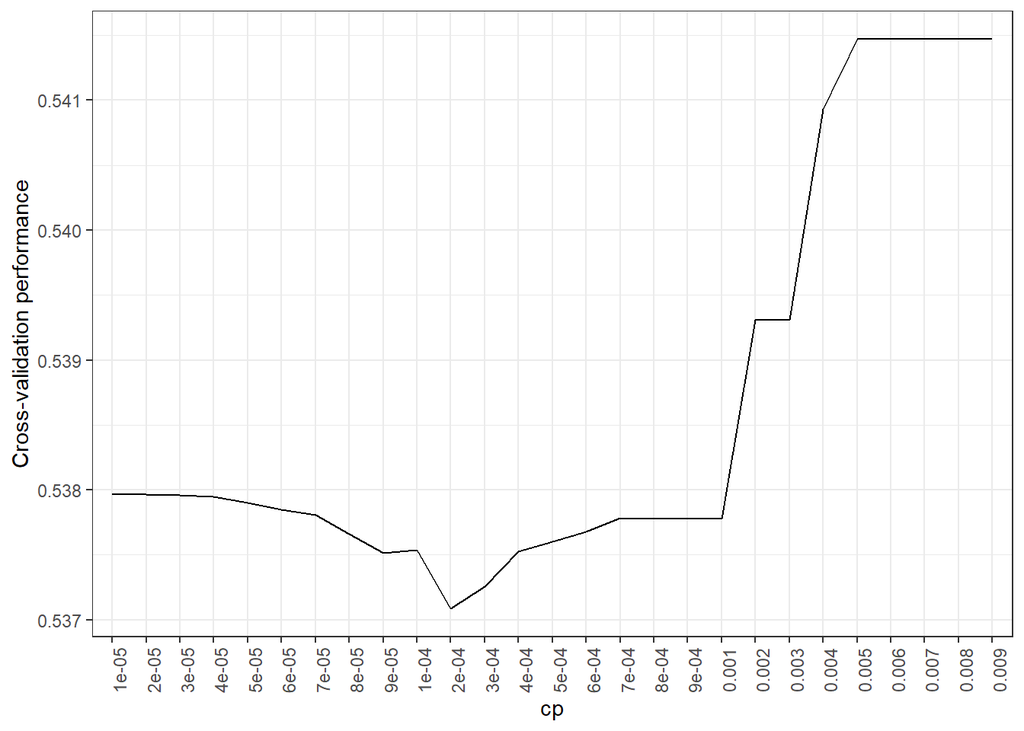

```r
library(ggplot2)
ggplot(data.table('cp' = as.factor(cp_grid), 'perf' = cv_perf), aes(cp, perf, group = 1)) + geom_line() + theme_bw() + theme(axis.text.x = element_text(angle = 90)) + ylab('Cross-validation performance')
```

# Interpretation tools

This section covers some tools that can help to get insights from the fitted models.

## Variable importance

In this section we will investigate the variable importance in the fitted tree and gbm models. We start by loading the `ggplot2` package to create some nice graphs:

```r
library(ggplot2)
```

The most important variables in the frequency regression tree are (by far) the bonus-malus level and the age of the policyholder:

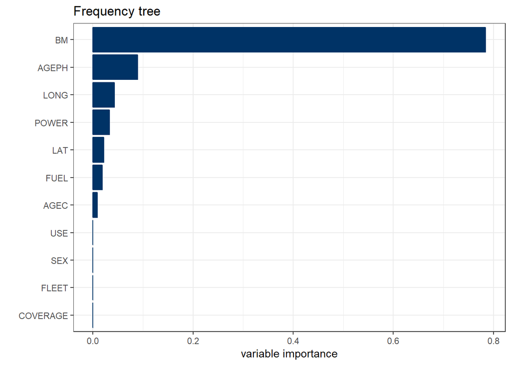

```r
vi <- tree_freq$variable.importance
vi[attr(tree_freq$terms, 'term.labels')[!(attr(tree_freq$terms, 'term.labels') %in% names(vi))]] = 0

DTvi <- data.table(variable = names(vi), vi = vi)
DTvi <- DTvi[, vi := round(vi/sum(vi), digits = 4)][order(-vi)]

ggplot(DTvi, aes(reorder(variable,vi),vi)) + geom_col(colour = '#003366',fill = '#003366') + coord_flip() + theme_bw() + labs(x = '', y = 'variable importance') + ggtitle('Frequency tree')
```

The most important variables in the frequency gbm are the bonus-malus level, the age of the policyholders and the spatial information:

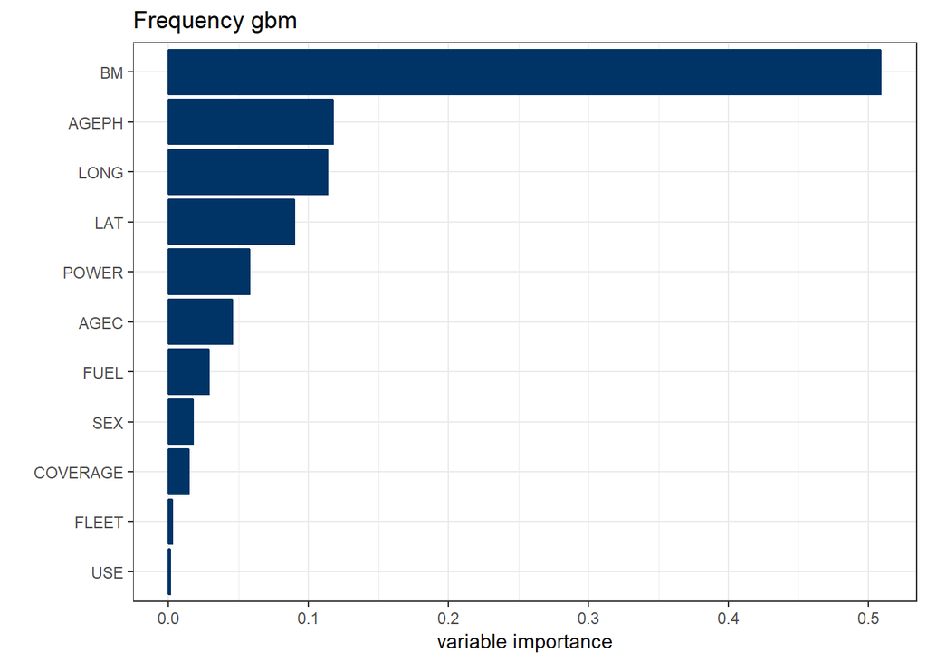

```r
df_vi <- summary(gbm_freq, plotit = FALSE, normalize = FALSE)
vi <- mapply(function(x,y) { y }, as.character(df_vi$var), df_vi$rel.inf, SIMPLIFY = TRUE, USE.NAMES = TRUE)

DTvi <- data.table(variable = names(vi), vi = vi)
DTvi <- DTvi[, vi := round(vi/sum(vi), digits = 4)][order(-vi)]

ggplot(DTvi, aes(reorder(variable,vi),vi)) + geom_col(colour = '#003366',fill = '#003366') + coord_flip() + theme_bw() + labs(x = '', y = 'variable importance') + ggtitle('Frequency gbm')
```

## Partial dependence plots

In this section we present some insights from the fitted tree and gbm models through partial dependence plots. See https://christophm.github.io/interpretable-ml-book/pdp.html for an intro to these types of plots. Whereas the tutorial on gradient boosting with the CRAN package `gbm` was using the built-in partial dependence plots (at the level of the predictor) we now code the pdp ourselves, at the level of the response.

### Age of the policyholder

We first look at the age effect in the frequency tree. Notice the step-wise behaviour, which is typical for a regression tree. We can observe that young policyholder pose a higher risk regarding claim frequency and the risk declines with increasing age.

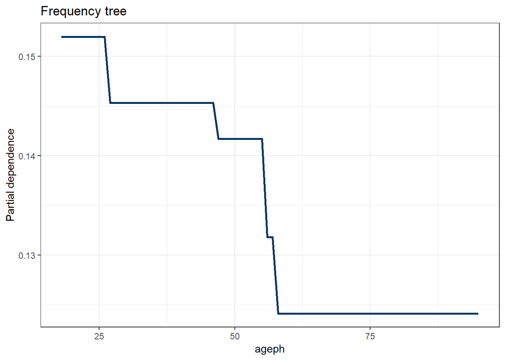

```r
DTeffect <- data.table('AGEPH' = seq(min(data$AGEPH), max(data$AGEPH)))
data_copy <- data.table::copy(data)
effect <- sapply(1:nrow(DTeffect),
                 function(i) mean(predict(tree_freq, data_copy[,'AGEPH' := DTeffect[i, 'AGEPH', with=FALSE]])))
DTeffect[, 'effect' := effect]

ggplot(DTeffect, aes(x = AGEPH, y = effect)) + geom_line(colour = '#003366', size = 1) + theme_bw() + xlab('ageph') + ylab('Partial dependence') + ggtitle('Frequency tree')
```

Now we compare this with the age effect in the frequency gbm. Notice that the effect is much smoother compared to the regression tree effect. There is also an increase in risk for senior policyholders, which was not captured by the regression tree.

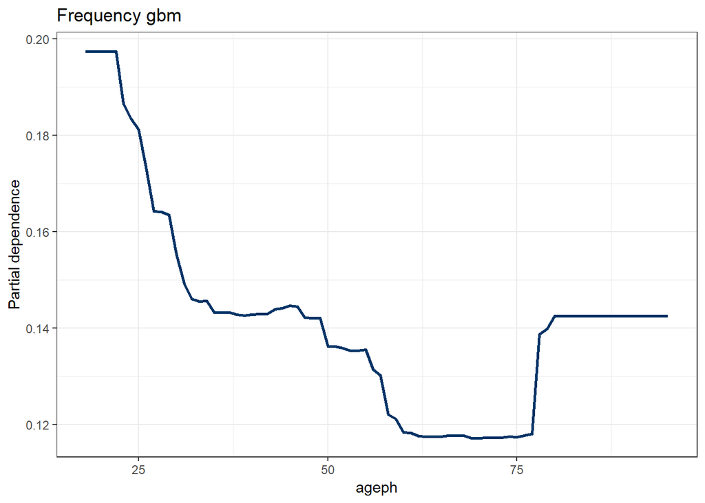

```r
DTeffect <- data.table('AGEPH' = seq(min(data$AGEPH), max(data$AGEPH)))
data_copy <- data.table::copy(data)
effect <- sapply(1:nrow(DTeffect),
                 function(i) mean(predict(gbm_freq, data_copy[,'AGEPH' := DTeffect[i, 'AGEPH', with=FALSE]], type = 'response', n.trees = gbm_freq$n.trees)))
DTeffect[, 'effect' := effect]

ggplot(DTeffect, aes(x = AGEPH, y = effect)) + geom_line(colour = '#003366', size = 1) + theme_bw() + xlab('ageph') + ylab('Partial dependence') + ggtitle('Frequency gbm')
```

### Spatial effect

We start by defining a function to read the shape file of Belgium, which we need to make plots on the Belgian map:

```r
library(rgdal)
library(ggmap)
setwd('C:/Users/u0043788/Dropbox/Data science for non-life insurance/Computer labs/Tree-based ML')
readShapefile = function(){
  belgium_shape <- readOGR(dsn = path.expand(paste(getwd(),"/Shape file Belgie postcodes",sep="")), layer = "npc96_region_Project1")
  belgium_shape <- spTransform(belgium_shape, CRS('+proj=longlat +datum=WGS84'))
  belgium_shape$id <- row.names(belgium_shape)
  return(belgium_shape)
}
```

We first look at the spatial effect in the frequency tree. Notice the squared behaviour on the map of Belgium. This is the 2D equivalent of the previously observed step-wise effect. Brussels clearly pops out as the most risky area to reside and drive a car.

```r
DTeffect <- data.table('LONG' = unname(coordinates(readShapefile())[,1]),
                       'LAT' = unname(coordinates(readShapefile())[,2]))
data_copy <- data.table::copy(data)
effect <- sapply(1:nrow(DTeffect),
                 function(i) mean(predict(tree_freq, data_copy[, c('LONG','LAT') := DTeffect[i, c('LONG','LAT'), with=FALSE]])))
DTeffect[, 'effect' := effect]

belgium_shape <- readShapefile()
```

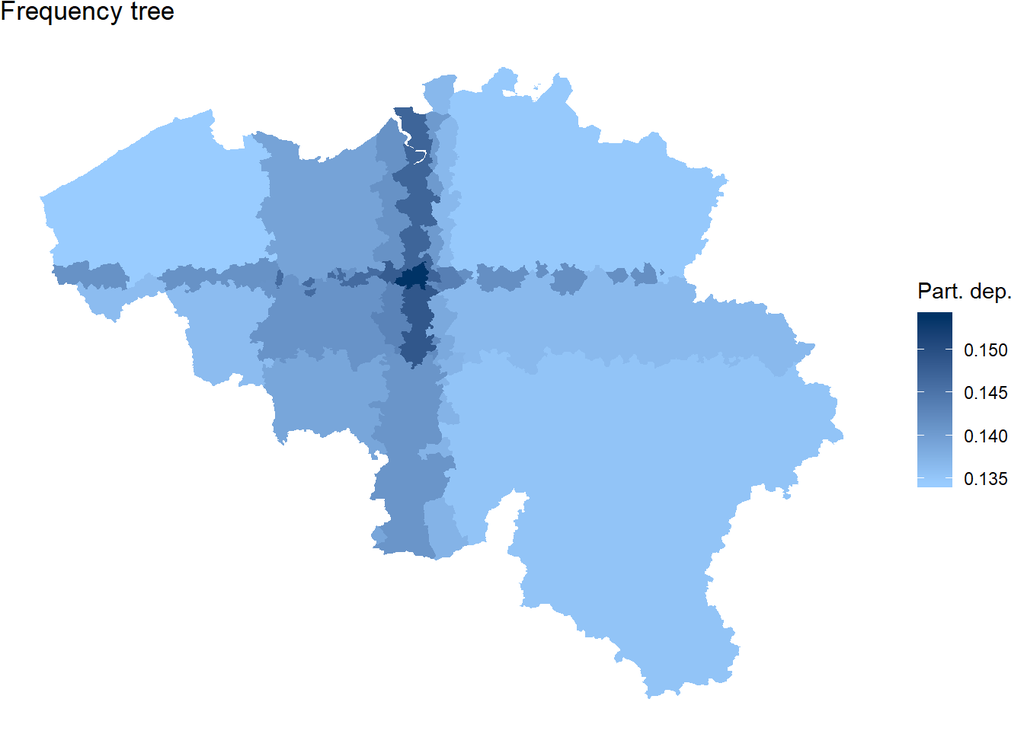

```r
belgium_shape@data <- cbind(belgium_shape@data, DTeffect[,'effect'])
belgium_shape_f <- fortify(belgium_shape)
belgium_shape_f <- merge(belgium_shape_f, belgium_shape@data, all.x = TRUE)
ggplot(belgium_shape_f, aes(long, lat, group = group)) + geom_polygon(aes(fill = belgium_shape_f$effect)) + scale_fill_gradient(low='#99CCFF',high='#003366') + theme_nothing(legend = TRUE) + labs(fill='Part. dep.') + ggtitle('Frequency tree')
```

Now we compare this with the spatial effect in the frequency gbm. We can see that the same trend is followed as in the regression tree, but again in a much smoother way. Brussels still pops out as the most risky area to reside regarding claim frequency.

```r
DTeffect <- data.table('LONG' = unname(coordinates(readShapefile())[,1]),
                       'LAT' = unname(coordinates(readShapefile())[,2]))
data_copy <- data.table::copy(data)
effect <- sapply(1:nrow(DTeffect),
                 function(i) mean(predict(gbm_freq, data_copy[, c('LONG','LAT') := DTeffect[i, c('LONG','LAT'), with=FALSE]], type = 'response', n.trees = gbm_freq$n.trees)))
DTeffect[, 'effect' := effect]

belgium_shape <- readShapefile()
```

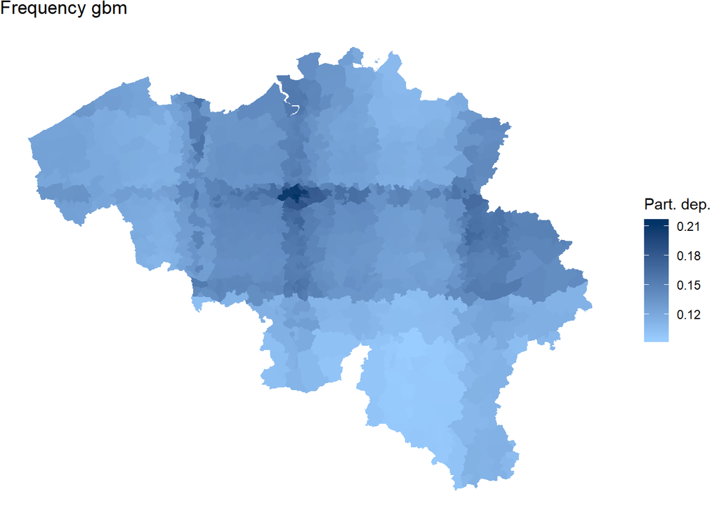

```r
belgium_shape@data <- cbind(belgium_shape@data, DTeffect[,'effect'])
belgium_shape_f <- fortify(belgium_shape)
belgium_shape_f <- merge(belgium_shape_f, belgium_shape@data, all.x = TRUE)
ggplot(belgium_shape_f, aes(long, lat, group = group)) + geom_polygon(aes(fill = belgium_shape_f$effect)) + scale_fill_gradient(low='#99CCFF',high='#003366') + theme_nothing(legend = TRUE) + labs(fill='Part. dep.') + ggtitle('Frequency gbm')
```

## Individual conditional expectations

In this section we will try to get some more insights from the fitted tree and gbm models through individual conditional expectations. See https://christophm.github.io/interpretable-ml-book/ice.html for an intro to these types of plots.

### Age of the policyholder

We first look at the age effect in the frequency tree. The blue line is the same one as we saw previously in the PDP section. The grey lines show the effect of the age on individual policyholder level. The blue line can be interpreted as the average effect of all these grey lines. We can again see a clear trend in decreasing riskiness with increasing age, although there are some risk profiles where the riskiness increases with increasing age.

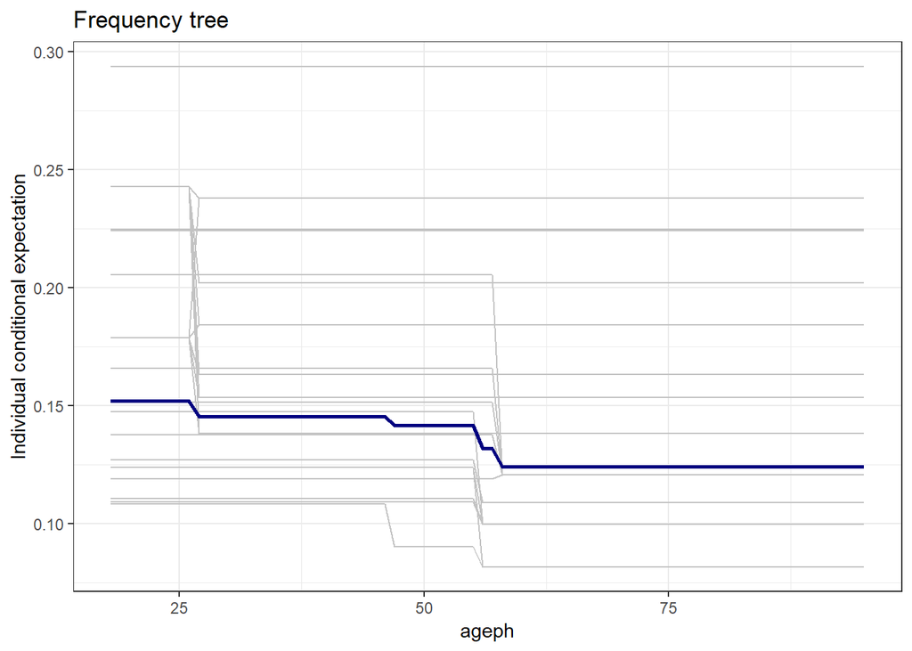

```r
DTeffect <- data.table('AGEPH' = seq(min(data$AGEPH), max(data$AGEPH)))
data_copy <- data.table::copy(data)
effect <- sapply(1:nrow(DTeffect),
                 function(i) predict(tree_freq, data_copy[,'AGEPH' := DTeffect[i, 'AGEPH', with=FALSE]]))
DTeffect <- cbind(DTeffect, t(effect))

set.seed(54321)
# Select 10 000 random profiles for the ice curves
ice_profiles <- c(1,sample(2:ncol(DTeffect),10000))
ggplt <- ggplot()
# Add the ice curves
ggplt <- ggplt + geom_line(data = melt(DTeffect[, ice_profiles, with = FALSE], id.vars = 'AGEPH'), aes(x = AGEPH, y = value, group = variable), alpha = 0.1, colour = 'grey75')
# Add the pdp curve
ggplt <- ggplt + geom_line(data = data.table('AGEPH' = DTeffect[['AGEPH']], 'effect' = rowMeans(DTeffect[, 2:ncol(DTeffect)])), aes(x = AGEPH, y = effect, group = 1), colour = 'navy', size = 1)
# Add some style
ggplt <- ggplt + theme_bw() + xlab('ageph') + ylab('Individual conditional expectation') + ggtitle('Frequency tree')
ggplt
```

Now we compare this with the age effect in the frequency gbm. The effect is again much smoother compared to the regression tree and also on individual policyholder level there seems to be a monotonous decrease in riskiness with an increase for senior policyholders.

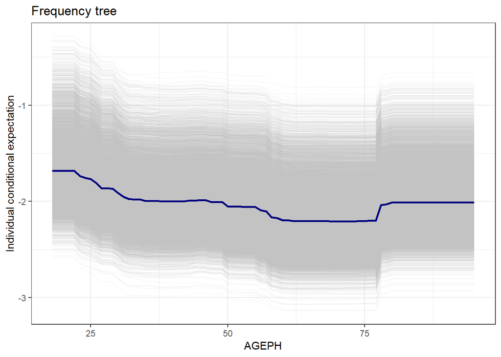

```r
DTeffect <- data.table('AGEPH' = seq(min(data$AGEPH), max(data$AGEPH)))
data_copy <- data.table::copy(data)
effect <- sapply(1:nrow(DTeffect),
                 function(i) predict(gbm_freq, data_copy[,'AGEPH' := DTeffect[i, 'AGEPH', with=FALSE]]))
DTeffect <- cbind(DTeffect, t(effect))

set.seed(54321)
# Select 10 000 random profiles for the ice curves
ice_profiles <- c(1,sample(2:ncol(DTeffect), 10000))
ggplt <- ggplot()
# Add the ice curves
ggplt <- ggplt + geom_line(data = melt(DTeffect[, ice_profiles, with = FALSE], id.vars = 'AGEPH'), aes(x = AGEPH, y = value, group = variable), alpha = 0.1, colour = 'grey75')
# Add the pdp curve
ggplt <- ggplt + geom_line(data = data.table('AGEPH' = DTeffect[['AGEPH']], 'effect' = rowMeans(DTeffect[, 2:ncol(DTeffect)])), aes(x = AGEPH, y = effect, group = 1), colour = 'navy', size = 1)
# Add some style
ggplt <- ggplt + theme_bw() + xlab('AGEPH') + ylab('Individual conditional expectation') + ggtitle('Frequency tree')
ggplt
```

# Economic value

To wrap up this tutorial we add some final words on the economic value of different models, also called the model lift. This does not necessarily refer to actual profits, but more towards the possibility for an insurance company to avoid adverse selection. For some information on model lift, see Chapter 7 of this document: https://www.casact.org/pubs/monographs/papers/05-Goldburd-Khare-Tevet.pdf.

You should now carefully read Section 5 in the paper on Model lift: from analytic to managerial insights. This Section discusses useful tools for an economic comparison of different tariffs.

```r
# this code can be used to extract the R code from an R Markdown (Rmd) document
library(knitr)
setwd('C:/Users/u0043788/Dropbox/Data science for non-life insurance/Computer labs/Tree-based ML')
file.exists("2019-05-01 Tree-based ML.Rmd")
purl("2019-05-01 Tree-based ML.Rmd")
```